# Machine learning final assignment: Barbel lift, how well do they do it?

## Model explanation

With this assignment the goal is to predict classification of barbell lifts into A,B,C,D,E. We start with exploring the data. We realize that there are many NA’s so we start cleaning the data by removing high NA columns. We perform both Hold-out test as well as cross validation based on this [stack answer](https://stats.stackexchange.com/questions/104713/hold-out-validation-vs-cross-validation) as we have 19 thousand Data points! CV is used typically if the dataset is small. Both are used to understand the Model Accuracy.

### Expected out of sample error calculation!

Based on [this](https://github.com/lgreski/datasciencectacontent/blob/master/markdown/pml-requiredModelAccuracy.md), we are able to calculate the following:

The following table illustrates the probability of predicting all 20 test cases right, given a particular model accuracy.

| Model Accuracy | Probability of Predicting 20 out of 20 Correctly |
| --- | --- |
| 0.800 | 0.0115 |
| 0.850 | 0.0388 |
| 0.900 | 0.1216 |
| 0.950 | 0.3585 |
| 0.990 | 0.8179 |
| 0.995 | 0.9046 |

We thus aim for a model accuracy of 99.5% atleast so that the expected out of sample accuracy will be in the order of 90%.

## Start of R programming!

```r
library(caret,corrplot)
```

The training data for this project are available here:

https://d396qusza40orc.cloudfront.net/predmachlearn/pml-training.csv

The test data are available here:

https://d396qusza40orc.cloudfront.net/predmachlearn/pml-testing.csv

```r
f.training <- read.csv("./pml-training.csv")
f.testing <- read.csv("./pml-testing.csv")
```

## Explore Data

```r
dim(f.training)
```

```
## [1] 19622   160
```

```r
sum(is.na(f.training))
```

```
## [1] 1287472
```

Other explorations were done with `head`, `names` etc… but is not showed here due to the large output. With the `sum` function we see that there are a lot of NA’s, so we get into cleaning the data.

## Cleaning DATA

```r
## Cleaning Removing high NA cols

ncol(f.training)
```

```
## [1] 160
```

```r
nas <- lapply(f.training,function(X) sum(is.na(X)))> 0.90*nrow(f.training)
f.training <- f.training[,!nas]
f.testing <- f.testing[,!nas]
ncol(f.training)
```

```
## [1] 93
```

```r
## Cleaning Removing Zero Var Cols

NZV <- nearZeroVar(f.training)
f.training <- f.training[,-NZV]
f.testing <- f.testing[,-NZV]
ncol(f.training)
```

```
## [1] 59
```

```r
## cleaning removing meaningless variables such as name

MLV <- 1:5
f.training <- f.training[,-MLV]
f.testing <- f.testing[,-MLV]
ncol(f.training)
```

```
## [1] 54
```

## Partition the data

```r
inTrain <- createDataPartition(y=f.training$classe,p=0.7,list=F)
training <- f.training[inTrain,]
testing <- f.training[-inTrain,]
```

## Model fit Decision tree!

We start with the Decision Tree as here we are primary interested in a classification type of problem. Based on [this](https://stats.stackexchange.com/questions/61783/bias-and-variance-in-leave-one-out-vs-k-fold-cross-validation) we choose a CV K-fold of 10.

```r
trControl <- trainControl(method="cv",number=10)
modFitDT <- train(classe~.,method="rpart",data=training,trControl=trControl)

predictionDT <- predict(modFitDT,testing)
confusionMatrix(predictionDT,testing$classe)$overall['Accuracy']
```

```
##  Accuracy
## 0.5690739
```

The accuracy of the decision tree seems to be really bad. Increasing the CV number doesn’t seem to help! The decision tree is shown below:

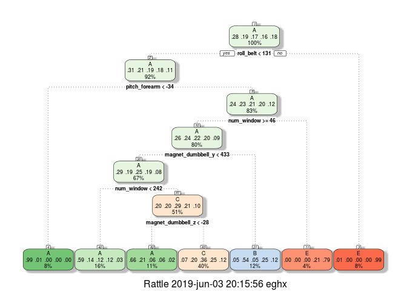

```r
library(rattle)
fancyRpartPlot(modFitDT$finalModel)
```

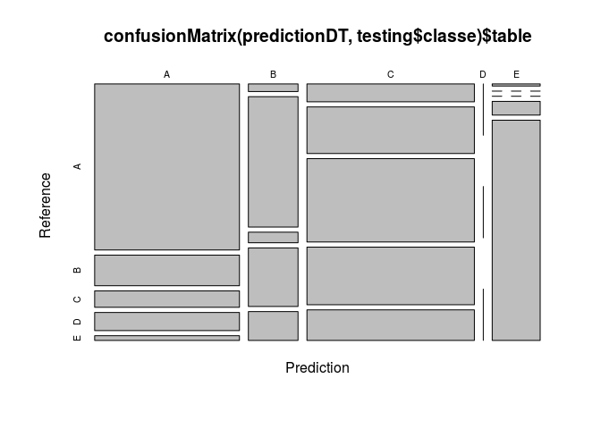

```r
plot(confusionMatrix(predictionDT,testing$classe)$table)
```

## Model Fit Random Forests

Next we try Random Forests. This following code uses 3 cores, and allows running in parallel for a time of 5 mins instead of 20 mins, on an 8gb ram system. The code is based off of : [Github link of Len](https://github.com/lgreski/datasciencectacontent/blob/master/markdown/pml-randomForestPerformance.md).

```r
library(parallel)
library(doParallel)
cluster <- makeCluster(detectCores() - 1) # convention to leave 1 core for OS
registerDoParallel(cluster)

trControl <- trainControl(method = "cv",
                           number = 5,
                          allowParallel = TRUE)

modFitRF <- train(classe~.,data=training,method="rf", trControl=trControl)

stopCluster(cluster)
registerDoSEQ()

predictionRF <- predict(modFitRF,testing)
confusionMatrix(predictionRF,testing$classe)$overall['Accuracy']
```

```
##  Accuracy
## 0.9979609
```

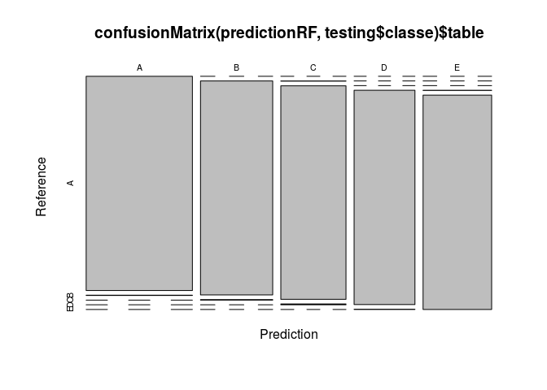

```r
plot(confusionMatrix(predictionRF,testing$classe)$table)
```

## Final Prediction

```r
prediction.finale <- predict(modFitRF,f.testing)
prediction.finale
```

```
##  [1] B A B A A E D B A A B C B A E E A B B B
## Levels: A B C D E
```

This led to a 100% prediction on the Quiz! :)

## Appendix: Question copied from Coursera!

Using devices such as Jawbone Up, Nike FuelBand, and Fitbit it is now possible to collect a large amount of data about personal activity relatively inexpensively. These type of devices are part of the quantified self movement – a group of enthusiasts who take measurements about themselves regularly to improve their health, to find patterns in their behavior, or because they are tech geeks. One thing that people regularly do is quantify how much of a particular activity they do, but they rarely quantify how well they do it. In this project, your goal will be to use data from accelerometers on the belt, forearm, arm, and dumbell of 6 participants. They were asked to perform barbell lifts correctly and incorrectly in 5 different ways. More information is available from the website here: http://web.archive.org/w eb/20161224072740/http:/groupware.les.inf.puc-rio.br/har (see the section on the Weight Lifting Exercise Dataset).

The training data for this project are available here:

https://d396qusza40orc.cloudfront.net/predmachlearn/pml-training.csv

The test data are available here:

https://d396qusza40orc.cloudfront.net/predmachlearn/pml-testing.csv

The data for this project come from this source: http://web.archive.org/web/20161224072740/http:/groupware.les.inf.puc-rio.br/har. If you use the document you create for this class for any purpose please cite them as they have been very generous in allowing their data to be used for this kind of assignment.

The training data for this project are available here:

https://d396qusza40orc.cloudfront.net/predmachlearn/pml-training.csv

The test data are available here:

https://d396qusza40orc.cloudfront.net/predmachlearn/pml-testing.csv

> The data for this project come from this source: http://web.archive.org/web/20161224072740/http:/groupware.les.inf.puc-rio.br/har. If you use the document you create for this class for any purpose please cite them as they have been very generous in allowing their data to be used for this kind of assignment. - from [website](http://web.archive.org/web/20161224072740/http:/groupware.les.inf.puc-rio.br/har#weight_lifting_exercises)

> Six young health participants were asked to perform one set of 10 repetitions of the Unilateral Dumbbell Biceps Curl in five different fashions: exactly according to the specification (Class A), throwing the elbows to the front (Class B), lifting the dumbbell only halfway (Class C), lowering the dumbbell only halfway (Class D) and throwing the hips to the front (Class E). - from [website](http://web.archive.org/web/20161224072740/http:/groupware.les.inf.puc-rio.br/har#weight_lifting_exercises)